# Logistic Regression Classification Model

## Multivariate Analysis

Multivariate analysis involves examining relationships between multiple variables simultaneously. We can use techniques like principal component analysis (PCA) or clustering to identify patterns and groups in the data.

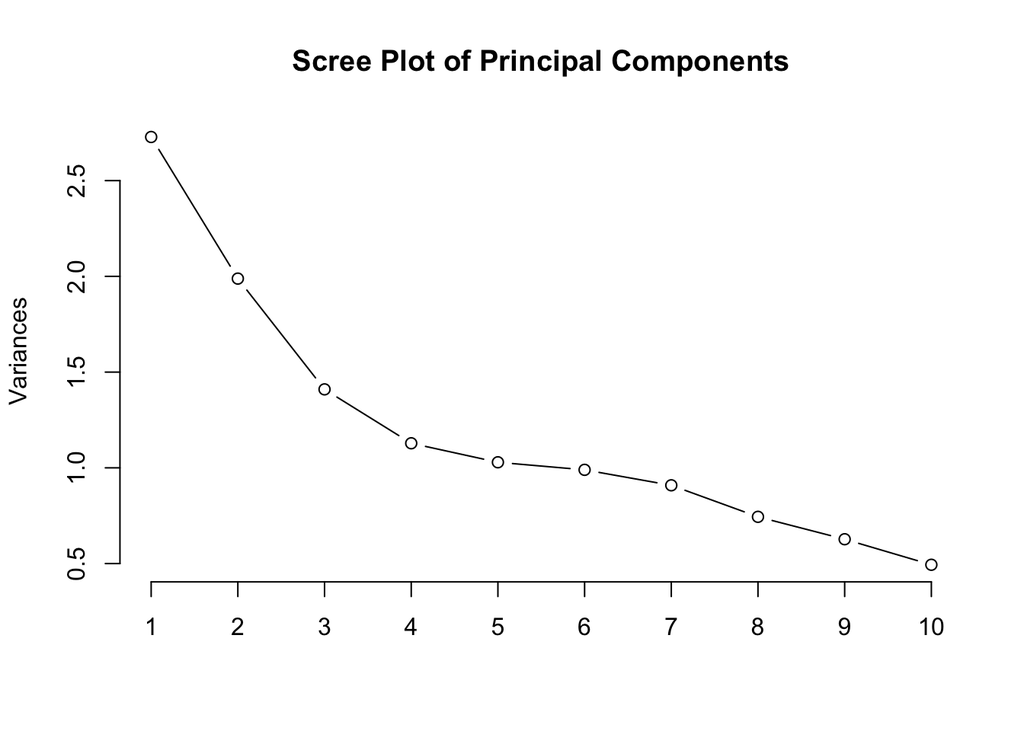

```r
# Principal Component Analysis (PCA)
pca_vars <- loan_data %>%
  select_if(is.numeric)

pca_result <- prcomp(pca_vars, scale. = TRUE)

# Scree plot
screeplot(pca_result, type = "lines",
          main = "Scree Plot of Principal Components")
```

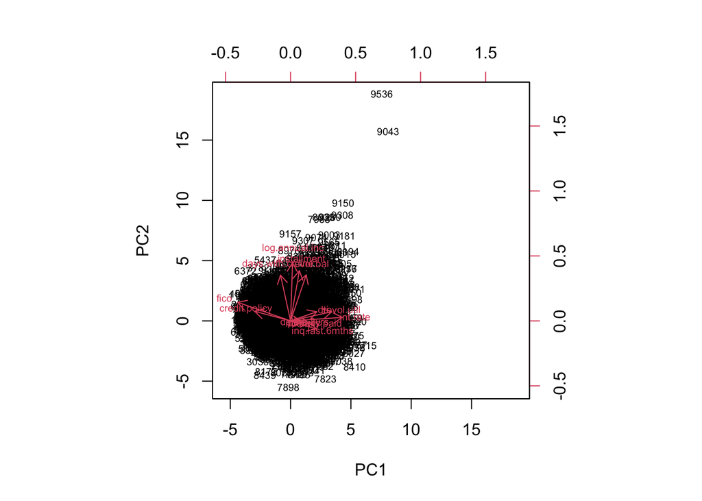

```r
# Biplot
biplot(pca_result, scale = 0, cex = 0.6)
```

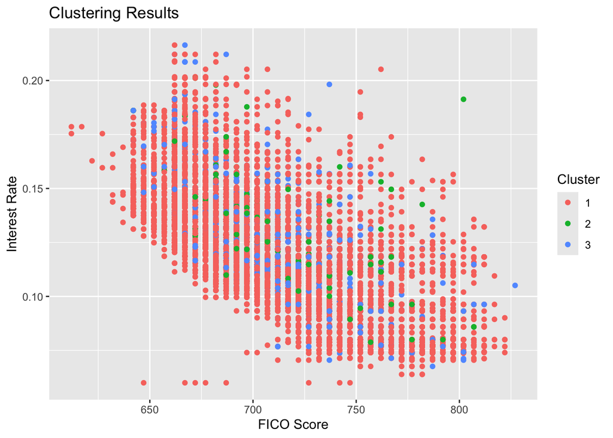

```r
# Clustering (K-means)
set.seed(123)
kmeans_result <- kmeans(pca_vars, centers = 3)

# Visualize clusters
ggplot(pca_vars, aes(x = fico, y = int.rate, color = factor(kmeans_result$cluster))) +
  geom_point() +
  labs(title = "Clustering Results", x = "FICO Score", y = "Interest Rate", color = "Cluster")
```

## Missing Data and Outliers

Identifying and handling missing data and outliers is an important step in EDA. We can use functions like is.na(), sum(), and colSums() to check for missing values and visualizations like box plots or scatter plots to identify potential outliers.

```r
# Check for missing values
colSums(is.na(loan_data))
```

```
##     credit.policy           purpose          int.rate       installment
##                 0                 0                 0                 0
##    log.annual.inc               dti              fico days.with.cr.line
##                 0                 0                 0                 0
##         revol.bal        revol.util    inq.last.6mths       delinq.2yrs
##                 0                 0                 0                 0
##           pub.rec    not.fully.paid
##                 0                 0
```

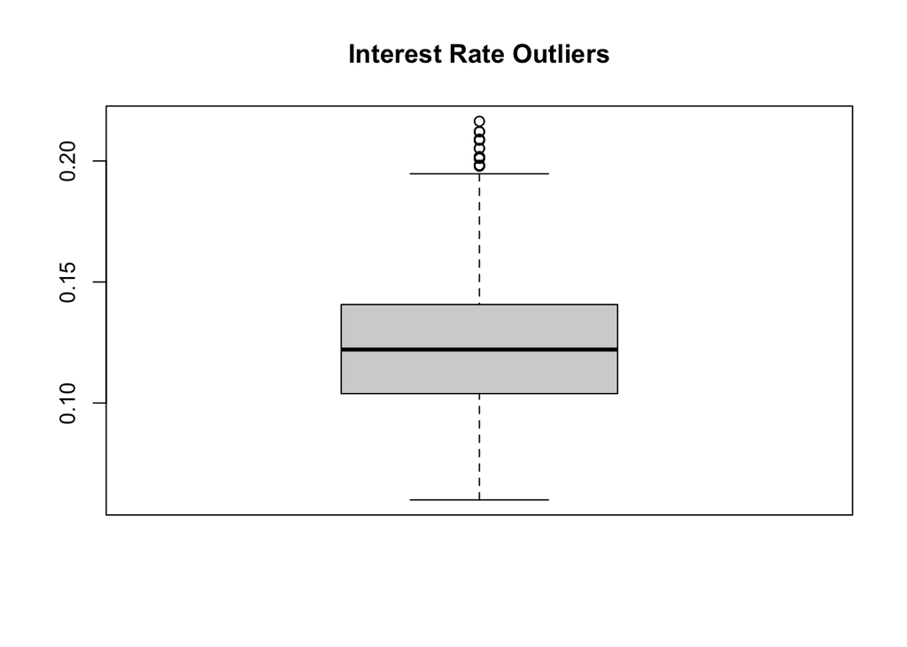

```r
# Identify outliers using box plots
boxplot(loan_data$int.rate, main = "Interest Rate Outliers")
```

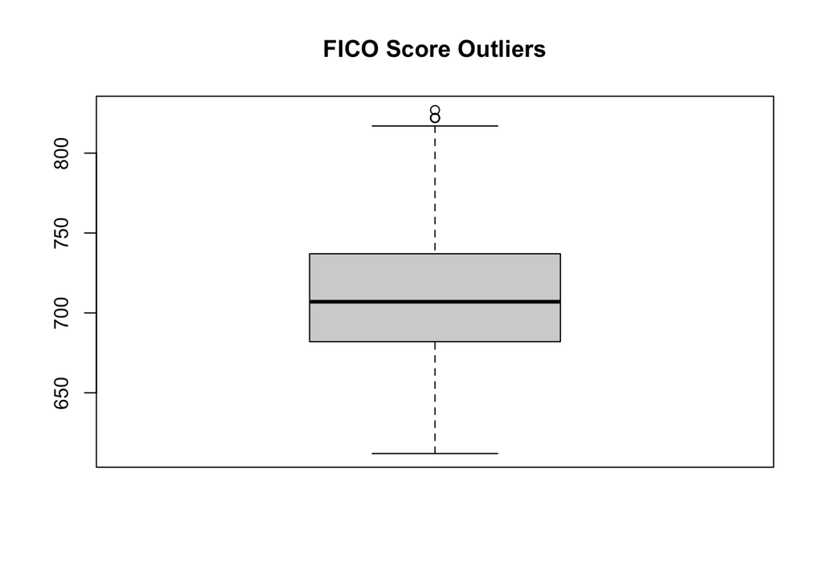

```r
boxplot(loan_data$fico, main = "FICO Score Outliers")
```

Box Plot of FICO Score Outliers

Description: This box plot focuses on identifying outliers in the FICO scores. It shows the distribution of FICO scores and highlights any points that lie outside the typical range.

Interpretation: Outliers can indicate data entry errors, unusual loan applicants, or exceptional cases. Understanding these outliers is crucial for data quality and analysis.

Based on the analysis, we can decide on appropriate strategies for handling missing data and outliers, such as imputation, removal, or transformation.

# Data Preprocessing

Data preprocessing is a crucial step in preparing the dataset for modeling. It involves handling missing data, scaling features, encoding categorical variables, and selecting relevant features.

## Handling Missing Data

Missing data can be dealt with using various techniques, such as removal, imputation, or advanced methods like multiple imputation.

```r
# Remove rows with missing values
loan_data_clean <- na.omit(loan_data)

# Impute missing values with mean or median
loan_data_imputed <- loan_data %>%
  mutate_if(is.numeric, funs(ifelse(is.na(.), mean(., na.rm = TRUE), .)))
```

```r
# Min-max scaling
min_max_scale <- function(x) {
  (x - min(x)) / (max(x) - min(x))
}

loan_data_scaled <- loan_data %>%
  mutate_if(is.numeric, min_max_scale)

# Standardization (Z-score scaling)
loan_data_standardized <- loan_data %>%
  mutate_if(is.numeric, scale)
```

```r
# One-hot encoding
library(caret)
dummies <- dummyVars(~ purpose, data = loan_data)
loan_data_encoded <- predict(dummies, newdata = loan_data)

# Label encoding
loan_data$purpose_encoded <- as.numeric(factor(loan_data$purpose))
```

```r
# Correlation-based feature selection
#library(caret)

#corr_matrix <- cor(loan_data %>% select_if(is.numeric))
#high_corr_vars <- findCorrelation(corr_matrix, cutoff = 0.7)

#loan_data_selected <- loan_data %>%
#  select(-high_corr_vars)

# Recursive Feature Elimination (RFE)
#control <- rfeControl(functions = rfFuncs, method = "cv", number = 5)
#results <- rfe(loan_data %>% select(-credit.policy), loan_data$credit.policy,
               #sizes = c(1:10), rfeControl = control)

#print(results)
```

Techniques like correlation-based feature selection, recursive feature elimination (RFE), or domain knowledge can be used to select the most informative features.

# Data Splitting and Cross-Validation

We’ll split the data into training and testing sets and apply cross-validation to evaluate and tune our model.

```r
# Load caret for splitting and cross-validation
library(caret)

# Set seed for reproducibility
set.seed(123)

# Split the data
trainIndex <- createDataPartition(loan_data$credit.policy, p = .8,
                                  list = FALSE,
                                  times = 1)
loanTrain <- loan_data[trainIndex,]
loanTest <- loan_data[-trainIndex,]

# Check the distribution
table(loanTrain$credit.policy)
```

```
##
##    0    1
## 1484 6179
```

```r
table(loanTest$credit.policy)
```

```
##
##    0    1
##  384 1531
```

```r
# Define cross-validation settings
ctrl <- trainControl(method = "repeatedcv", number = 10, repeats = 3)
```

Data splitting ensures that we have separate datasets for training and testing the model, while cross-validation helps in assessing the model’s performance and selecting the best hyperparameters.

# Model Fitting

We will fit a logistic regression model using the training data and explore regularization techniques.

## Logistic Regression

Logistic regression is a statistical method for binary classification that models the probability of an event occurring based on a set of predictors.

```r
# Train logistic regression model
log_model <- glm(credit.policy ~ ., data = loanTrain, family = binomial)
# Summary of the model
summary(log_model)
```

```
##
## Call:
## glm(formula = credit.policy ~ ., family = binomial, data = loanTrain)
##
## Coefficients: (1 not defined because of singularities)
##                             Estimate Std. Error z value Pr(>|z|)
## (Intercept)               -3.596e+01  2.151e+00 -16.719  < 2e-16 ***
## purposecredit_card         4.292e-03  1.494e-01   0.029 0.977080
## purposedebt_consolidation  2.238e-01  1.132e-01   1.977 0.048068 *
## purposeeducational         7.723e-02  2.221e-01   0.348 0.728014
## purposehome_improvement    1.209e-01  1.948e-01   0.621 0.534814
## purposemajor_purchase      2.665e-01  2.336e-01   1.141 0.253961
## purposesmall_business      2.867e-01  2.005e-01   1.430 0.152673
## int.rate                   2.511e-01  2.695e+00   0.093 0.925768
## installment                1.016e-03  2.776e-04   3.661 0.000251 ***
## log.annual.inc             8.213e-01  8.910e-02   9.218  < 2e-16 ***
## dti                        5.109e-03  6.822e-03   0.749 0.453897
## fico                       4.284e-02  2.407e-03  17.802  < 2e-16 ***
## days.with.cr.line          1.264e-04  2.197e-05   5.752 8.80e-09 ***
## revol.bal                 -4.470e-05  2.097e-06 -21.317  < 2e-16 ***
## revol.util                 8.222e-03  1.862e-03   4.415 1.01e-05 ***
## inq.last.6mths            -9.687e-01  2.940e-02 -32.947  < 2e-16 ***
## delinq.2yrs               -1.521e-01  6.689e-02  -2.273 0.023000 *
## pub.rec                   -1.402e-03  1.555e-01  -0.009 0.992805
## not.fully.paid            -2.686e-01  1.044e-01  -2.573 0.010076 *
## purpose_encoded                   NA         NA      NA       NA
## ---
## Signif. codes:  0 '***' 0.001 '**' 0.01 '*' 0.05 '.' 0.1 ' ' 1
##
## (Dispersion parameter for binomial family taken to be 1)
##
##     Null deviance: 7532.5  on 7662  degrees of freedom
## Residual deviance: 3724.5  on 7644  degrees of freedom
## AIC: 3762.5
##
## Number of Fisher Scoring iterations: 7
```

The model summary provides information about the coefficients, their significance, and the overall model performance.

## Regularization Techniques

Regularization techniques like L1 (Lasso) and L2 (Ridge) can help prevent overfitting and improve model generalization.

```r
# Lasso regularization
library(glmnet)
x <- model.matrix(credit.policy ~ ., loanTrain)[,-1]
y <- loanTrain$credit.policy

cv_lasso <- cv.glmnet(x, y, family = "binomial", alpha = 1, nfolds = 10)
lasso_model <- glmnet(x, y, family = "binomial", alpha = 1,
                      lambda = cv_lasso$lambda.min)

# Ridge regularization
cv_ridge <- cv.glmnet(x, y, family = "binomial", alpha = 0, nfolds = 10)
ridge_model <- glmnet(x, y, family = "binomial", alpha = 0,
                      lambda = cv_ridge$lambda.min)
```

Lasso regularization performs feature selection by driving some coefficients to zero, while Ridge regularization shrinks the coefficients towards zero without complete elimination.

## Model Interpretation

Interpreting the logistic regression model involves understanding the coefficients and their impact on the outcome.

```r
# Odds ratios
exp(coef(log_model))
```

```
##               (Intercept)        purposecredit_card purposedebt_consolidation
##              2.416670e-16              1.004301e+00              1.250851e+00
##        purposeeducational   purposehome_improvement     purposemajor_purchase
##              1.080294e+00              1.128519e+00              1.305371e+00
##     purposesmall_business                  int.rate               installment
##              1.332085e+00              1.285385e+00              1.001017e+00
##            log.annual.inc                       dti                      fico
##              2.273386e+00              1.005122e+00              1.043772e+00
##         days.with.cr.line                 revol.bal                revol.util
##              1.000126e+00              9.999553e-01              1.008256e+00
##            inq.last.6mths               delinq.2yrs                   pub.rec
##              3.795699e-01              8.589288e-01              9.985991e-01
##            not.fully.paid           purpose_encoded
##              7.644872e-01                        NA
```

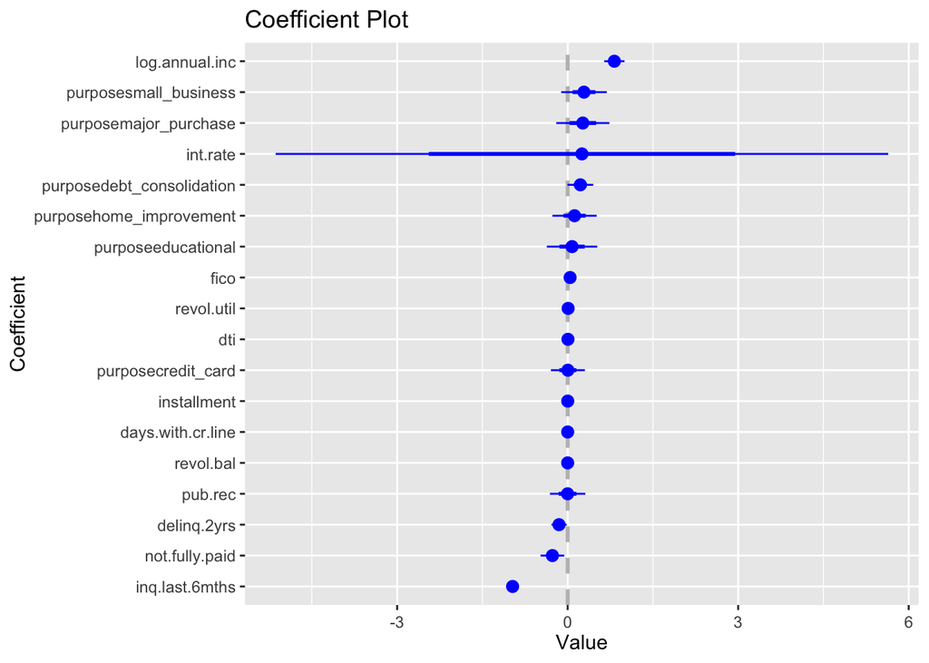

```r
# Visualize coefficients
library(coefplot)
coefplot(log_model, sort = "magnitude", intercept = FALSE)
```

Odds ratios represent the change in the odds of the outcome for a one-unit increase in the predictor, while coefficient plots provide a visual representation of the variable importance.

# Model Selection and Performance Evaluation

We will evaluate the model’s performance using various metrics and techniques.

## Hyperparameter Tuning

Hyperparameter tuning involves finding the optimal values for the model’s hyperparameters to improve its performance.

```r
library(caret)
library(glmnet)

# Define the control parameter
ctrl <- trainControl(method = "cv", number = 10)

# Define the tuning grid
param_grid <- expand.grid(
  alpha = 1,  # Set alpha to 1 for LASSO regression
  lambda = seq(0.001, 1, length.out = 20)
)

# Train the model with the specified grid
log_model_tune <- train(
  credit.policy ~ .,
  data = loanTrain,
  method = "glmnet",  # Use glmnet for LASSO or Ridge regression
  family = "binomial",
  trControl = ctrl,
  tuneGrid = param_grid
)
# Print the model summary
print(log_model_tune)
```

```
## glmnet
##
## 7663 samples
##   14 predictor
##
## No pre-processing
## Resampling: Cross-Validated (10 fold)
## Summary of sample sizes: 6896, 6897, 6897, 6896, 6897, 6897, ...
## Resampling results across tuning parameters:
##
##   lambda      RMSE       Rsquared   MAE
##   0.00100000  3.4508412  0.3820340  2.6712603
##   0.05357895  1.3031883  0.3613571  1.0661200
##   0.10615789  0.8602071  0.3146435  0.7512596
##   0.15873684  0.7264978  0.2869834  0.6479754
##   0.21131579  0.7348803  0.2297086  0.6201067
##   0.26389474  0.7352095        NaN  0.6200848
##   0.31647368  0.7352095        NaN  0.6200848
##   0.36905263  0.7352095        NaN  0.6200848
##   0.42163158  0.7352095        NaN  0.6200848
##   0.47421053  0.7352095        NaN  0.6200848
##   0.52678947  0.7352095        NaN  0.6200848
##   0.57936842  0.7352095        NaN  0.6200848
##   0.63194737  0.7352095        NaN  0.6200848
##   0.68452632  0.7352095        NaN  0.6200848
##   0.73710526  0.7352095        NaN  0.6200848
##   0.78968421  0.7352095        NaN  0.6200848
##   0.84226316  0.7352095        NaN  0.6200848
##   0.89484211  0.7352095        NaN  0.6200848
##   0.94742105  0.7352095        NaN  0.6200848
##   1.00000000  0.3951251        NaN  0.3123263
##
## Tuning parameter 'alpha' was held constant at a value of 1
## RMSE was used to select the optimal model using the smallest value.
## The final values used for the model were alpha = 1 and lambda = 1.
```

Grid search is a common technique for hyperparameter tuning, where a range of values for each hyperparameter is specified, and the model is trained and evaluated for each combination.

## Model Evaluation Metrics

Various evaluation metrics can be used to assess the performance of a binary classification model.

```r
# Predict on the test set
predictions <- predict(log_model, newdata = loanTest, type = "response")

# Convert probabilities to class labels
pred_class <- ifelse(predictions > 0.5, 1, 0)

# Accuracy
accuracy <- sum(pred_class == loanTest$credit.policy) / length(pred_class)

# Precision
precision <- sum(pred_class == 1 & loanTest$credit.policy == 1) / sum(pred_class == 1)

# Recall
recall <- sum(pred_class == 1 & loanTest$credit.policy == 1) / sum(loanTest$credit.policy == 1)

# F1 score
f1_score <- 2 * precision * recall / (precision + recall)

# Print the metrics
cat("Accuracy:", accuracy, "\n")
```

```
## Accuracy: 0.9049608
```

```r
cat("Precision:", precision, "\n")
```

```
## Precision: 0.9181649
```

```r
cat("Recall:", recall, "\n")
```

```
## Recall: 0.9673416
```

```r
cat("F1 Score:", f1_score, "\n")
```

```
## F1 Score: 0.942112
```

Accuracy: 0.9049608 - This indicates that the model correctly predicted the loan status for approximately 90.5% of the instances in the test dataset.

Precision: 0.9181649 - Precision measures the proportion of true positive predictions among all positive predictions. A precision of 0.9181649 means that when the model predicted a loan as “approved,” it was correct 91.82% of the time.

Recall: 0.9673416 - Recall, also known as sensitivity or true positive rate, represents the proportion of actual positive instances that were correctly identified by the model. A recall of 0.9673416 suggests that the model successfully identified 96.73% of the actual approved loans.

F1 Score: 0.942112 - The F1 score is the harmonic mean of precision and recall, providing a balanced measure of the model’s performance. An F1 score of 0.942112 indicates a strong overall performance, considering both precision and recall.

## Confusion Matrix

A confusion matrix provides a tabular summary of the model’s performance by comparing the predicted and actual class labels.

```r
# Confusion matrix
conf_matrix <- table(Predicted = pred_class, Actual = loanTest$credit.policy)
conf_matrix
```

```
##          Actual
## Predicted    0    1
##         0  252   50
##         1  132 1481
```

The confusion matrix shows the counts of true positives (TP), true negatives (TN), false positives (FP), and false negatives (FN), which can be used to derive various evaluation metrics.

## ROC Curve and AUC

The Receiver Operating Characteristic (ROC) curve plots the true positive rate (sensitivity) against the false positive rate (1-specificity) at different classification thresholds. The Area Under the Curve (AUC) is a measure of the model’s discriminatory power.

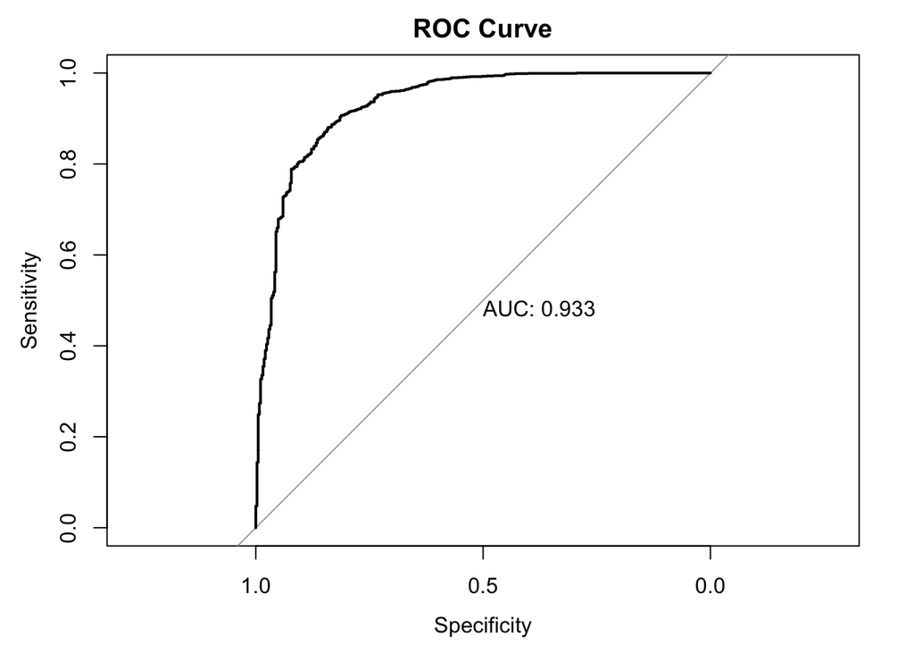

```r
# ROC curve and AUC
library(pROC)
roc_obj <- roc(loanTest$credit.policy, predictions)
plot(roc_obj, main = "ROC Curve", print.auc = TRUE)
```

ROC Curve and AUC Description: The ROC (Receiver Operating Characteristic) curve shows the performance of a classification model. The AUC (Area Under the Curve) quantifies this performance.

Interpretation: A higher AUC value indicates better model performance in distinguishing between classes. The curve closer to the top left corner represents a better performing model, indicating high true positive rates and low false positive rates. This graph is essential for evaluating the effectiveness of the predictive model.

## Precision-Recall Curve

The Precision-Recall curve shows the trade-off between precision and recall at different classification thresholds.

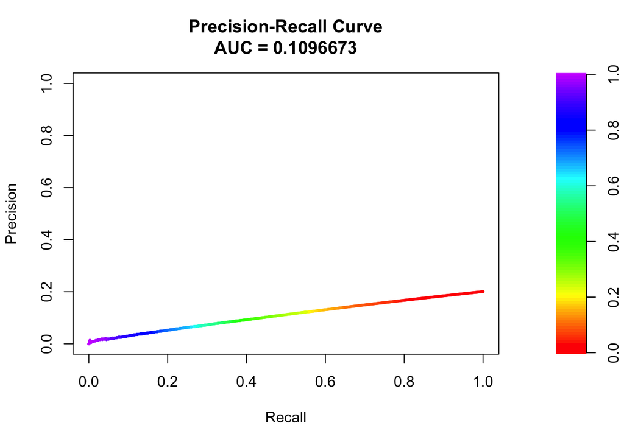

```r
# Precision-Recall curve
library(PRROC)

pr_curve <- pr.curve(scores.class0 = predictions[loanTest$credit.policy == 0],
                     scores.class1 = predictions[loanTest$credit.policy == 1],
                     curve = TRUE)

plot(pr_curve, main = "Precision-Recall Curve")
```

The Precision-Recall curve is particularly useful when dealing with imbalanced datasets, where the positive class is rare.

# Model Deployment and Practical Considerations

Once the model is trained and evaluated, it’s important to consider its deployment and practical aspects.

## Saving and Loading Models

Saving trained models allows for future use without the need to retrain them.

```r
# Save the model
saveRDS(log_model, file = "logistic_model.rds")

# Load the saved model
loaded_model <- readRDS("logistic_model.rds")
```

Deploying models can be done through various methods, such as creating web services, integrating with databases, or using cloud platforms like AWS, GCP, or Azure.

## Model Monitoring and Maintenance

Monitoring dashboards can track the model’s performance metrics over time, alert when performance degrades, and provide insights for model retraining or updates.

# Conclusion

Accuracy: 0.9049608

Precision: 0.9181649

Recall: 0.9673416

F1 Score: 0.942112

The high accuracy of 0.9049608 indicates that the model correctly predicted the loan status for a significant proportion of the instances. The precision of 0.9181649 suggests that when the model predicted a loan as “approved,” it was correct 91.82% of the time. The recall of 0.9673416 implies that the model successfully identified 96.73% of the actual approved loans. The F1 score of 0.942112, which is the harmonic mean of precision and recall, provides a balanced measure of the model’s performance.

While the logistic regression model performed well, there is still room for improvement. Further exploration of alternative algorithms, such as decision trees, random forests, or support vector machines, could potentially enhance the predictive power. Additionally, feature engineering techniques, such as creating interaction terms or transforming variables, may help capture more complex relationships between the predictors and the loan status.

One thing to consider is the model’s performance on different subgroups of the population. It would be valuable to examine the model’s fairness and ensure that it does not exhibit biases based on sensitive attributes such as gender, race, or age. Techniques like stratified sampling or regularization methods can be employed to mitigate potential biases.

When deploying the model in a production environment, it is crucial to establish a monitoring and validation process. Regularly evaluating the model’s performance on new, unseen data and updating the model as needed is essential to ensure its continued effectiveness. Additionally, setting up a feedback loop to gather insights from loan officers and incorporating their domain knowledge can further refine the model.

In conclusion, the logistic regression model developed in this project demonstrates a promising approach for predicting loan statuses based on various predictors. The model’s performance, as measured by accuracy, precision, recall, and F1 score, suggests its potential for real-world application. However, there are opportunities for further improvement through exploration of alternative algorithms, feature engineering, fairness considerations, and incorporation of additional data sources. By continuously monitoring and updating the model, we can ensure its robustness and reliability in supporting loan approval decisions. This project serves as a foundation for developing more sophisticated and accurate loan prediction models that can assist financial institutions in making data-driven decisions while promoting responsible lending practices.

# Future Work

While I have built a logistic regression model that performs reasonably well, there are several areas for future exploration and improvement.

## Alternative Algorithms

Logistic regression is just one of many algorithms suitable for binary classification tasks. Other algorithms such as decision trees, random forests, support vector machines (SVM), or gradient boosting methods like XGBoost and LightGBM could be explored to compare their performance with logistic regression.

```r
# Example using random forest
library(randomForest)
rf_model <- randomForest(credit.policy ~ ., data = loanTrain)
rf_predictions <- predict(rf_model, newdata = loanTest)
```

## Advanced Feature Engineering

Feature engineering plays a crucial role in improving model performance. Advanced techniques such as interaction terms, polynomial features, or domain-specific transformations could be applied to create more informative features.

```r
# Example of creating interaction terms
loanTrain$interaction_term <- loanTrain$int.rate * loanTrain$fico
loanTest$interaction_term <- loanTest$int.rate * loanTest$fico

# Fit the model with the interaction term
log_model_interaction <- glm(credit.policy ~ . + interaction_term, data = loanTrain, family = binomial)
```

## Ensemble Methods

Ensemble methods combine multiple models to make predictions, often resulting in improved performance compared to individual models. Techniques like bagging, boosting, or stacking could be explored to create ensemble models.

```r
# Example using stacking
#library(caretEnsemble)

# Define the base models
#model_list <- list(
 # model1 = train(credit.policy ~ ., data = loanTrain, method = "glm", family = "binomial"),
  #model2 = train(credit.policy ~ ., data = loanTrain, method = "rf"),
  #model3 = train(credit.policy ~ ., data = loanTrain, method = "xgbTree")
#)

# Create the stacked model
#stack_model <- caretStack(model_list, method = "glm", metric = "Accuracy", trControl = ctrl)

# Make predictions using the stacked model
#stack_predictions <- predict(stack_model, newdata = loanTest)
```

# References

https://www.kaggle.com/datasets/itssuru/loan-data?resource=download

James, G., Witten, D., Hastie, T., & Tibshirani, R. (2013). An introduction to statistical learning (Vol. 112, p. 18). New York: springer.

Kuhn, M., & Johnson, K. (2019). Feature engineering and selection: A practical approach for predictive models. CRC Press.

Molnar, C. (2019). Interpretable machine learning: A guide for making black box models explainable. Lulu. com.

# Appendix

## Additional Visualizations

Here are some additional visualizations that provide further insights into the dataset and the model’s performance.

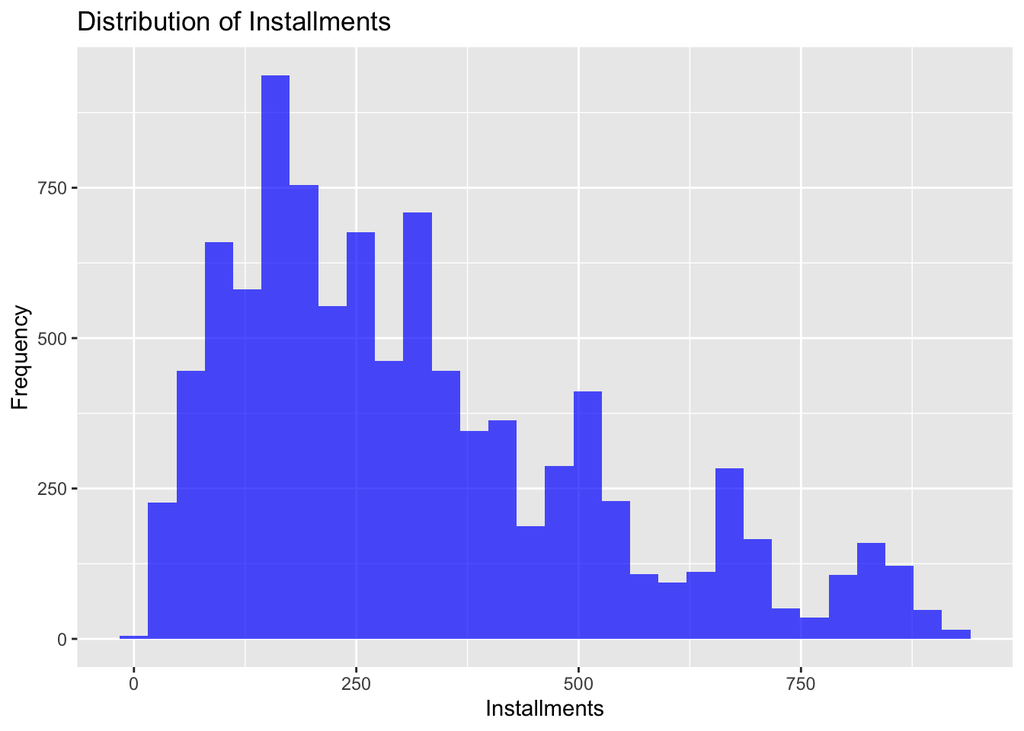

```r
# Distribution of loan amount
ggplot(loan_data, aes(x = installment)) +
  geom_histogram(bins = 30, fill = "blue", alpha = 0.7) +
  labs(title = "Distribution of Installments", x = "Installments", y = "Frequency")
```

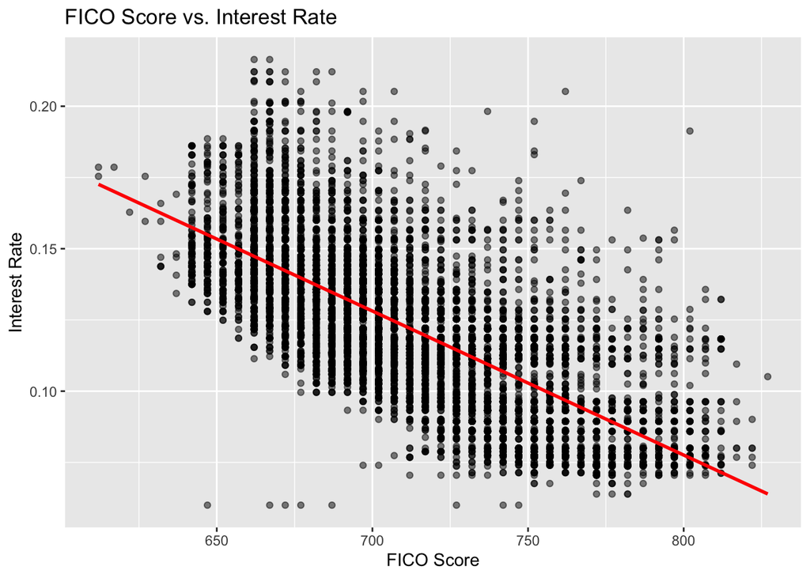

```r
# Relationship between FICO score and interest rate
ggplot(loan_data, aes(x = fico, y = int.rate)) +
  geom_point(alpha = 0.5) +
  geom_smooth(method = "lm", se = FALSE, color = "red") +
  labs(title = "FICO Score vs. Interest Rate", x = "FICO Score", y = "Interest Rate")
```

These visualizations can help in understanding the distribution of key variables and the relationships between predictors and the target variable.

## Dataset Description

The loan dataset used in this project contains information about loan applicants and their loan statuses. Here is a brief description of the variables:

credit.policy: Binary variable indicating if the customer meets the credit underwriting criteria (1) or not (0).

purpose: The purpose of the loan (debt consolidation, credit card, etc.).

int.rate: The interest rate of the loan.

installment: The monthly installment amount.

log.annual.inc: The natural log of the self-reported annual income of the borrower.

dti: The debt-to-income ratio of the borrower.

fico: The FICO credit score of the borrower.

days.with.cr.line: The number of days the borrower has had a credit line.

revol.bal: The borrower’s revolving balance.

revol.util: The borrower’s revolving line utilization rate.

inq.last.6mths: The borrower’s number of inquiries by creditors in the last 6 months.

delinq.2yrs: The number of times the borrower had been 30+ days past due on a payment in the past 2 years.

pub.rec: The borrower’s number of derogatory public records.

not.fully.paid: Binary variable indicating if the loan was not fully paid (1) or fully paid (0).